# Ejemplo Carlos De Castilla

Carlos De Castilla

# Ejercicio Carlos De Castilla Parrilla

## Enunciado del problema

Unos amigos quieren pasar la noche en el casino y jugarse parte de sus ahorros en alguno de los distintos juegos que se ofrecen en las mesas del salón quieren decidir en cuál es más rentable jugar. Los distintos juegos son: El Bingo, El Blackjack, El Póker y La Ruleta.

## Planteamiento:

- Un único decisor.
- Modelo de beneficios (FAVORABLE).
- Alternativas:
  - d1 = “Bingo”
  - d2 = “Blackjack”
  - d3 = “Póker”
  - d4 = “Ruleta”
- Estados de la Naturaleza:
  - e1 = “Muy mala suerte”
  - e2 = “Mala suerte”
  - e3 = “Suerte neutra”
  - e4 = “Buena suerte”
  - e5 = “Muy buena suerte”
- A continuación represento la tabla de valores (ganancias en €): Juego: (Suerte) // Muy mala // Mala // Neutra // Buena // Muy Buena //  
  Bingo: // -40 // -30 // -10 // 10 // 30 // Blackjack: // -40 // -20 // -10 // 20 // 40 // Póker: // -120 // -60 // -30 // 50 // 150 // Ruleta: // -140 // -90 // -10 // 60 // 170 //

## Resolución

Como bien nos dice el enunciado del trabajo, el problema ejemplo que hay crear individualmente tiene que ser resuelto, en primer lugar, empleando todos los métodos de incertidumbre, y despúes resolverlo con la función creada por el grupo en conjunto.

Para probar que todos los métodos funcionan podríamos usar ciertas funciones de la librería de funciones ya creada “*teoriadecision_funciones_incertidumbre.R*”

```r
datos=c(-40,-30,-10,10,30,
        -40,-20,-10,20,40,
        -120,-60,-30,50,150,
        -140,-90,-10,60,170)

matriz=crea.tablaX(datos,4,5)
matriz
```

```
##      e1  e2  e3 e4  e5
## d1  -40 -30 -10 10  30
## d2  -40 -20 -10 20  40
## d3 -120 -60 -30 50 150
## d4 -140 -90 -10 60 170
```

Aplicamos ahora *criterio.Todos* de la librería de funciones anterior, la cual está cargada al inicio de este fichero, supuesto un modelo favorable y para un cierto valor de alpha (usamos la función *criterio.Todos* puesto que es la que nos aplica todos los métodos de incertidumbre en conjunto sin tener que estar tediosamente aplicando los métodos uno a uno.

```r
solTodos = criterio.Todos(tablaX = matriz, alfa = 0.5,favorable = TRUE)
solTodos
```

```
##                   e1  e2  e3 e4  e5  Wald Optimista Hurwicz Savage  Laplace
## d1               -40 -30 -10 10  30   -40        30      -5    140       -8
## d2               -40 -20 -10 20  40   -40        40       0    130       -2
## d3              -120 -60 -30 50 150  -120       150      15     80       -2
## d4              -140 -90 -10 60 170  -140       170      15    100       -2
## iAlt.Opt (fav.)   --  --  -- --  -- d1,d2        d4   d3,d4     d3 d2,d3,d4
##                 Punto Ideal
## d1                   149.00
## d2                   136.01
## d3                    94.34
## d4                   122.07
## iAlt.Opt (fav.)          d3
```

Tenemos por tanto los siguientes resultados:

- Para el criterio Pesimista o de Wald la decisión correcta es Bingo o Blackjack, para el criterio optimista la mejor opción es la Ruleta, para el criterio de Hurwicz, la mejor alternativa sería jugar al Póker o a la Ruleta.

-Aplicando el método de Savage obtenemos que la alternativa de mínimo arrepentimiento sería jugar al Póker. Se jugaría también al Póker si nuestro método fuese el del Punto Ideal.

-Y por último si aplicáramos el criterio de Laplace (sucesos equiprobables) obtendríamos un empate entre las alternativas de jugar a Blackjack, Póker o Ruleta, por lo que se puede deducir que da igual jugar a cualquiera de esos 3 juegos.

## Resolución utilizando la función creada por el grupo

Haremos uso de nuestra función para obtener los distintos intervalos del alfa (alfa mide nuestra valentía siendo 0 muy pesimista y 1 muy optimista) en los que cambian las alternativas óptima. siendo el criterio de incertidumbre el método de **Hurwicz**. La función es la siguiente:

```r
# Función Principal (creada por el grupo)
intervalos.alfa= function(tablaX,favorable=TRUE) {

  alfa=seq(0,1,by=0.01) # Introducimos un conjunto de alfas que nos servirán
  # para saber cuándo cambia la alternativa óptima. Fijamos un valor de 0.01,
  # el cual indica cada cuánto se quiere que exista alfa.
  X = tablaX

  if(favorable){ #en el caso de que sea favorable
    Altmin = apply(X,MARGIN=1,min)
    Altmax= apply(X,MARGIN=1,max)

    # Como ya no tenemos un alfa, sino varios, debemos crear un bucle que
    # trabaje con todos los alfa. Como, además, Altmin y Altmax son vecto-
    # res, tenemos que crear listas que nos devuelvan, para cada elemento
    # de dichos vectores, cuáles son las alternativas asociadas a los
    # alfas.

    AltH=list()
    Hurwicz=list()
    Alt_Hurwicz=list()

    # Creamos el bucle:

    for(i in 1:length(alfa)){
      AltH[[i]] = alfa[i] * Altmax + (1-alfa[i]) * Altmin
      Hurwicz[[i]] = max(AltH[[i]])
      Alt_Hurwicz[[i]] = which.max.general(AltH[[i]])
    }

    metodo = 'favorable'

  } else { #en caso de que no sea favorable
    Altmin = apply(X,MARGIN=1,min)
    Altmax= apply(X,MARGIN=1,max)

    AltH=list()
    Hurwicz=list()
    Alt_Hurwicz=list()

    for(i in 1:length(alfa)){
      AltH[[i]] = (1-alfa[i]) * Altmax + alfa[i] * Altmin
      Hurwicz[[i]] = min(AltH[[i]])
      Alt_Hurwicz[[i]] = which.min.general(AltH[[i]])
    }

    metodo = 'desfavorable'

  }

  resultados = list();
  resultados$metodo = metodo;
  resultados$ValorAlternativa = unlist(Hurwicz); # Valores que toma cada
  # alfa en su alternativa óptima.
  resultados$alfa = alfa; # Alfas usados.
  resultados$AlternativaOptima = unlist(Alt_Hurwicz);
  resultados$Solucion = unlist(Alt_Hurwicz);
  names(resultados$Solucion)=alfa;
  # distinct(as.data.frame(resultados,alfa));
  prueba=cbind.data.frame(alfa,resultados$Solucion[1:length(alfa)]);
  colnames(prueba)<-c("Alfa", "Solución");
  rownames(prueba %>% distinct(Solución));
  alternativas= prueba %>% distinct(Solución);
  resultados$intervalos = alternativas
  return(resultados)
}
```

La aplicamos a nuestra matriz de datos:

```r
solHurwicz = intervalos.alfa(matriz, favorable = T)
solHurwicz
```

```
## $metodo
## [1] "favorable"
##
## $ValorAlternativa
##   [1] -40.0 -39.2 -38.4 -37.6 -36.8 -36.0 -35.2 -34.4 -33.6 -32.8 -32.0 -31.2
##  [13] -30.4 -29.6 -28.8 -28.0 -27.2 -26.4 -25.6 -24.8 -24.0 -23.2 -22.4 -21.6
##  [25] -20.8 -20.0 -19.2 -18.4 -17.6 -16.8 -16.0 -15.2 -14.4 -13.6 -12.8 -12.0
##  [37] -11.2 -10.4  -9.6  -8.8  -8.0  -7.2  -6.4  -3.9  -1.2   1.5   4.2   6.9
##  [49]   9.6  12.3  15.0  18.1  21.2  24.3  27.4  30.5  33.6  36.7  39.8  42.9
##  [61]  46.0  49.1  52.2  55.3  58.4  61.5  64.6  67.7  70.8  73.9  77.0  80.1
##  [73]  83.2  86.3  89.4  92.5  95.6  98.7 101.8 104.9 108.0 111.1 114.2 117.3
##  [85] 120.4 123.5 126.6 129.7 132.8 135.9 139.0 142.1 145.2 148.3 151.4 154.5
##  [97] 157.6 160.7 163.8 166.9 170.0
##
## $alfa
##   [1] 0.00 0.01 0.02 0.03 0.04 0.05 0.06 0.07 0.08 0.09 0.10 0.11 0.12 0.13 0.14
##  [16] 0.15 0.16 0.17 0.18 0.19 0.20 0.21 0.22 0.23 0.24 0.25 0.26 0.27 0.28 0.29
##  [31] 0.30 0.31 0.32 0.33 0.34 0.35 0.36 0.37 0.38 0.39 0.40 0.41 0.42 0.43 0.44
##  [46] 0.45 0.46 0.47 0.48 0.49 0.50 0.51 0.52 0.53 0.54 0.55 0.56 0.57 0.58 0.59
##  [61] 0.60 0.61 0.62 0.63 0.64 0.65 0.66 0.67 0.68 0.69 0.70 0.71 0.72 0.73 0.74
##  [76] 0.75 0.76 0.77 0.78 0.79 0.80 0.81 0.82 0.83 0.84 0.85 0.86 0.87 0.88 0.89
##  [91] 0.90 0.91 0.92 0.93 0.94 0.95 0.96 0.97 0.98 0.99 1.00
##
## $AlternativaOptima
## d1 d2 d2 d2 d2 d2 d2 d2 d2 d2 d2 d2 d2 d2 d2 d2 d2 d2 d2 d2 d2 d2 d2 d2 d2 d2
##  1  2  2  2  2  2  2  2  2  2  2  2  2  2  2  2  2  2  2  2  2  2  2  2  2  2
## d2 d2 d2 d2 d2 d2 d2 d2 d2 d2 d2 d2 d2 d2 d2 d2 d2 d2 d3 d3 d3 d3 d3 d3 d3 d3
##  2  2  2  2  2  2  2  2  2  2  2  2  2  2  2  2  2  2  3  3  3  3  3  3  3  3
## d4 d4 d4 d4 d4 d4 d4 d4 d4 d4 d4 d4 d4 d4 d4 d4 d4 d4 d4 d4 d4 d4 d4 d4 d4 d4
##  4  4  4  4  4  4  4  4  4  4  4  4  4  4  4  4  4  4  4  4  4  4  4  4  4  4
## d4 d4 d4 d4 d4 d4 d4 d4 d4 d4 d4 d4 d4 d4 d4 d4 d4 d4 d4 d4 d4 d4 d4 d4 d4
##  4  4  4  4  4  4  4  4  4  4  4  4  4  4  4  4  4  4  4  4  4  4  4  4  4
##
## $Solucion
##    0 0.01 0.02 0.03 0.04 0.05 0.06 0.07 0.08 0.09  0.1 0.11 0.12 0.13 0.14 0.15
##    1    2    2    2    2    2    2    2    2    2    2    2    2    2    2    2
## 0.16 0.17 0.18 0.19  0.2 0.21 0.22 0.23 0.24 0.25 0.26 0.27 0.28 0.29  0.3 0.31
##    2    2    2    2    2    2    2    2    2    2    2    2    2    2    2    2
## 0.32 0.33 0.34 0.35 0.36 0.37 0.38 0.39  0.4 0.41 0.42 0.43 0.44 0.45 0.46 0.47
##    2    2    2    2    2    2    2    2    2    2    2    2    3    3    3    3
## 0.48 0.49  0.5 0.51 0.52 0.53 0.54 0.55 0.56 0.57 0.58 0.59  0.6 0.61 0.62 0.63
##    3    3    3    3    4    4    4    4    4    4    4    4    4    4    4    4
## 0.64 0.65 0.66 0.67 0.68 0.69  0.7 0.71 0.72 0.73 0.74 0.75 0.76 0.77 0.78 0.79
##    4    4    4    4    4    4    4    4    4    4    4    4    4    4    4    4
##  0.8 0.81 0.82 0.83 0.84 0.85 0.86 0.87 0.88 0.89  0.9 0.91 0.92 0.93 0.94 0.95
##    4    4    4    4    4    4    4    4    4    4    4    4    4    4    4    4
## 0.96 0.97 0.98 0.99    1 <NA> <NA>
##    4    4    4    4    4    4    4
##
## $intervalos
##      Solución
## 0           1
## 0.01        2
## 0.44        3
## 0.52        4
```

Lo podemos comprobar realizando una representación gráfica mediante la función *dibuja.criterio.Hurwicz* de la librería “*teoriadecision_funciones_incertidumbre*”:

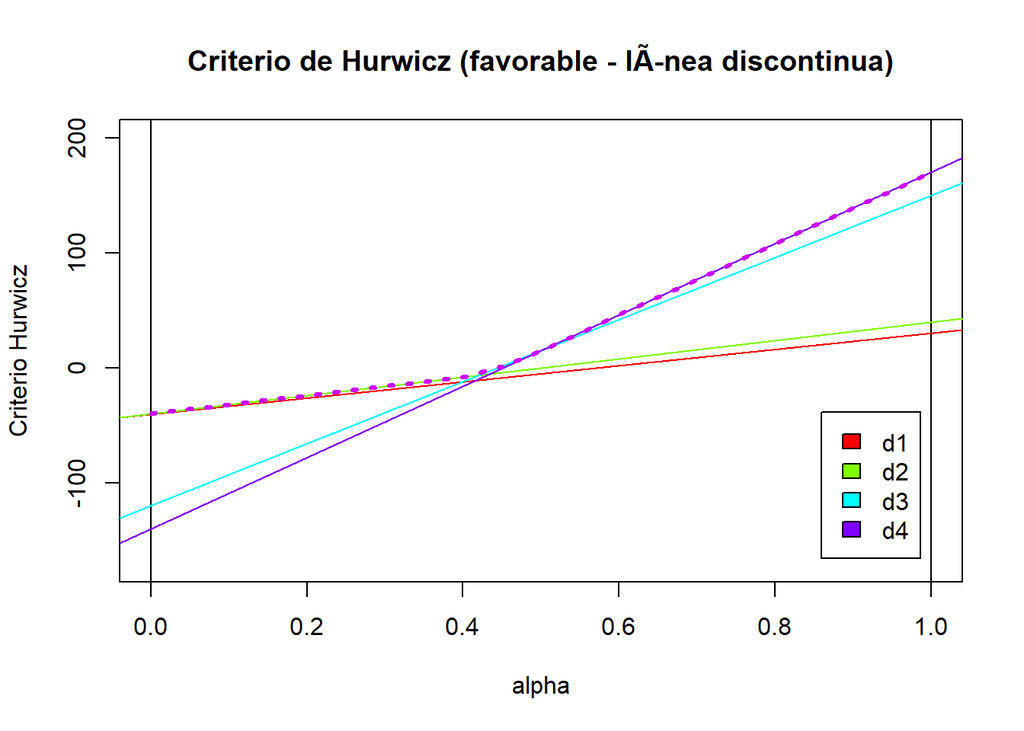

```r
dibuja.criterio.Hurwicz(matriz, favorable = T)
```